# comradesOO

Jonathan Price

# 1 The COMRADES experiment

- COMRADES determines in vivo RNA structures and interactions. (2018). Omer Ziv, Marta Gabryelska, Aaron Lun, Luca Gebert. Jessica Sheu-Gruttadauria and Luke Meredith, Zhong-Yu Liu, Chun Kit Kwok, Cheng-Feng Qin, Ian MacRae, Ian Goodfellow , John Marioni, Grzegorz Kudla, Eric Miska. Nature Methods. Volume 15. https://doi.org/10.1038/s41592-018-0121-0
- The Short- and Long-Range RNA-RNA Interactome of SARS-CoV-2. (2020). Omer Ziv, Jonathan Price, Lyudmila Shalamova, Tsveta Kamenova, Ian Goodfellow, Friedemann Weber, Eric A. Miska. Molecular Cell, Volume 80 https://doi.org/10.1016/j.molcel.2020.11.004

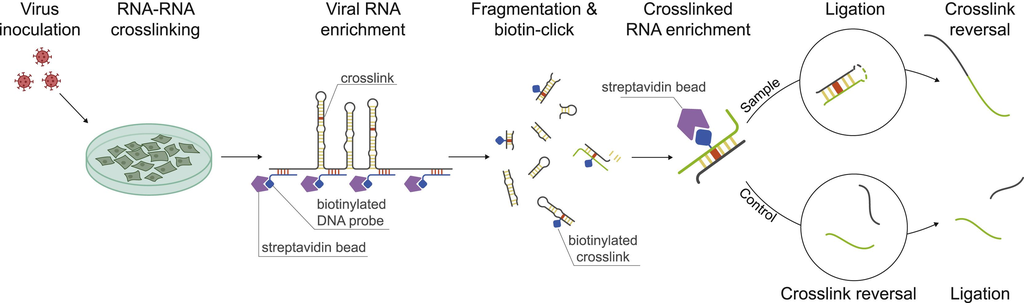

Figure from Ziv et al., 2020. Virus-inoculated cells are crosslinked using clickable psoralen. Viral RNA is pulled down from the cell lysate using an array of biotinylated DNA probes, following digestion of the DNA probes and fragmentation of the RNA. Biotin is attached to crosslinked RNA duplexes via click chemistry, enabling pulling down crosslinked RNA using streptavidin beads. Half of the RNA duplexes are proximity-ligated, following reversal of the crosslinking to enable sequencing. The other half serves as a control, in which crosslink reversal proceeds the proximity ligation

After sequencing, short reads are produced similar to a spliced / chimeric RNA read but where one half of the read corresponds to one half of a structural RNA duplex and the other half of the reads corresponds to the other half of the structural RNA duplex. This package has been designed to analyse this data. The short reads need to be prepared in a specific way to be inputted into this package.

There are other types of crosslinking data!

PARIS

# 2 COMRADES data pre-processing

## 2.1 Nextflow pipeline

Fastq files produced from the comrades experiment can be processed for input into comradesOO using the Nextflow pre-processing pipeline, to get more information visit here.. The pipeline takes the reads through trimming alignment, QC and the production of the files necessary for input to comradesOO. Crosslinking experiments often have different library preparation protocols therefore it is not necessary to follow the prescribed pre-processing pipeline. The only requirement is that the input files for comradesOO have the correct format detailed below.

## 2.2 Nextflow pipeline output

The main output files are the files entitled *X_gapped.txt*. These are the input files for comradesOO. The columns of the output files are as follows:

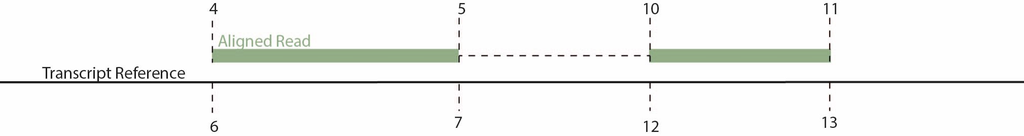

# 3 Input for comrades-OO

The main input files for comrades-OO is a tab delimited text file containing the reads and mapping location on the transcriptome. This can be manually created if your library preparation protocol does not suit the pre-processing pipeline although the easiest way to obtain these files is to use the nextflow pipeline detailed above. There is test data that ships with the package, this contains data for the 18S rRNA and it’s interactions with the 28S rRNA. However, full data-sets already published can be found here:[Un-enriched rRNA dataset](https://www.ncbi.nlm.nih.gov/geo/query/acc.cgi?acc=GSE246412).

Pre-requisites:

1. Install the comradesOO package
2. Input files (nexflow, custom or downloaded)
3. Meta-data table
4. ID of the RNA of interest (from the transcript reference )
5. A fasta sequence of the RNA of interest (from the transcript reference )
6. A set of interactions to compare to (optional)
7. Reactivities (optional)

## 3.1 Load the Library

There is a development version available on github (https://github.com/JLP-BioInf/comradesOO). Issue reporting and collaboration welcome.

```r
# Load the comrades-OO Library
#install.packages("comradesOO")
library(comradesOO)
```

The package relies on functions from these packages:

```r
# Here are the other libraries on which comradesOO relies
library(seqinr)
library(GenomicRanges)
library(ggplot2)
library(reshape2)
library(MASS)
library(ggplot2)
library(doParallel)
library(igraph)
library(R4RNA)
library(RColorBrewer)
library(heatmap3)
library(mixtools)
library(TopDom)
library(tidyverse)
library(RRNA)
library(ggrepel)
```

## 3.2 Make the Sample table

The metadata table has 4 columns and the column names are specific and case-sensitive.

- **file** - The input file name and location of the sample
- **group** - “c” or “s” denoting wether the sample is a control or not
- **sample** - Sample number
- **sampleName** - A unique sample name

```r
# Set up the sample table
sampleTableRow1 = c(system.file("extdata",
                                "s1.txt",
                                package="comradesOO"), "s", "1", "s1")
sampleTableRow2 = c(system.file("extdata",
                                "c1.txt",
                                package="comradesOO"), "c", "1", "c1")
sampleTable2 = rbind.data.frame(sampleTableRow1, sampleTableRow2)

# add the column names
colnames(sampleTable2) = c("file", "group", "sample", "sampleName")

sampleTable2
```

| file | group | sample | sampleName |
| --- | --- | --- | --- |
| /private/var/folders/dy/86vcj54d7bsgh2_dpqlf4l600000gn/T/RtmpB8ZReM/Rinst76c01edcdff1/comradesOO/extdata/s1.txt | s | 1 | s1 |
| /private/var/folders/dy/86vcj54d7bsgh2_dpqlf4l600000gn/T/RtmpB8ZReM/Rinst76c01edcdff1/comradesOO/extdata/c1.txt | c | 1 | c1 |

## 3.3 Choose RNA

The name of the RNA to analyse, this must be as it appears in the input files.

```r
rna = c("ENSG000000XXXXX_NR003286-2_RN18S1_rRNA")
```

## 3.4 Transript fasta

Fasta sequence(s) of the RNA(s) of interest, taken from the transcriptome reference fasta used for mapping. Load in using the read.fasta function from seqinr.

```r
path18SFata <- system.file("extdata",
                           "18S.fasta",
                           package="comradesOO")

rnaRefs = list()
rnaRefs[[rna]] = read.fasta(path18SFata)
```

## 3.5 A set of interactions to compare to (optional)

This is optional but you can provide a table of interactions for the RNA to compare against. This can be useful when comparing different samples or to another predicted structure for the same RNA. The table should be a tsv with to columns (i and j) each row shows an interaction between nucleotide i and j for comparison.

```r
path18SFata <- system.file("extdata",
                           "ribovision18S.txt",
                           package="comradesOO")
known18S = read.table(path18SFata,
                      header = F)
```

## 3.6 Reactivities (optional)

If you also have reactivities from a chemical probing experiment they can be included here as a 1 column table with one value for each position in the transcript. This feature is not ready.

```r
pathShape <- system.file("extdata",
                         "reactivities.txt",
                         package="comradesOO")
shape = read.table(pathShape,
                      header = F)
```

# 4 Slow Start

The package has 3 main processes; clustering, cluster trimming and folding. The next sections take you through the usage of each of these main stages.

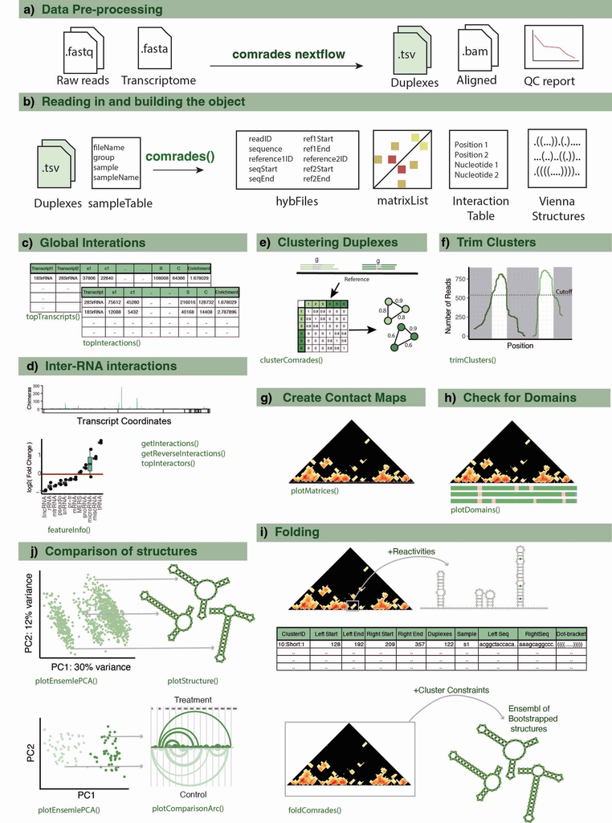

## 4.1 Make the Object

The instance of the *comradesDataSet* object that is created stores the information from the experiment including raw and processed data for the dataset.

### 4.1.1 Slots / Attributes

##### 4.1.1.0.1 Analysis stage

The slots for processed and unprocessed data keep the data from each stage of the analysis, this allows the user to quickly access any part of the results. Checking the status of the object will allow you to see which stages of the analysis are present for each of the attributes.

##### 4.1.1.0.2 Meta-data

- **rnas** - The RNA ID for this instance
- **rnaSize** - The size in nuceloties of the RNA for this instance
- **sampleTable** - The meta-data for the instance ( detailed above )

##### 4.1.1.0.3 Raw-data and processed data

- **hybFiles** - Data in the original input file format (list) hybFiles - rna ID - Analysis stage - Sample Name
- **matrixList** - Data in contact matrix format (list) (cells contain the number of reads assinged to those interacting coordinates) hybFiles - rna ID - Analysis stage - Sample Name
- **clusterGrangesList** - Granges of clusters identified (list) hybFiles - rna ID - Analysis stage - Sample Name
- **clusterTableList** - Data frame of clusters identified (list) hybFiles - rna ID - Analysis stage - Sample Name
- **clusterTableFolded** - A table of all clusters with predicted structures included
- **interactionTable** - A table contraints predicted for folding
- **viennaStructures** - A list of predicted structures in vienna format

### 4.1.2 comradesDataSet - make object

```r
# load the object
cds = comradesDataSet(rnas = rna,
                      sampleTable = sampleTable2)
```

```
#>  *****            COMRADES-OO          ******
#>  *****-------*******************-------******
#>  *****       Reading SampleTable       ******
#>  *****       Detected  2  Samples      ******
#>  *****     detected group c:: 2         *****
#>  *****     detected group s:: 1         *****
#>  ****      Sample Names:  s1 c1    ****  ****      Sample Names:  s1 c1    ****  ****      Sample Names:  s1 c1    ****  ****      Sample Names:  s1 c1    ****
#>  *****         Reading Hyb Files        *****
#>  *****     Getting RNAs of Interest    ******
#>  *****    RNA of interest + Host RNA    *****
#>  *****      RNA of interest Alone       *****
#>  *****         Making Matrices         ******
#>  *****          RNA Size:  1870         *****
#>  *****         Creating object          *****
#>  *****-------*******************-------******
```

## 4.2 Access the data within the instance

You can check on major parts of the object and return slots and other information using the accessor methods

### 4.2.1 General Acessors

#### 4.2.1.1 Check Status of Instance

```r
# Check status of instance
cds
```

```
#> comradesDataSet Object
#> RNAs Analysed                -              -  ENSG000000XXXXX_NR003286-2_RN18S1_rRNA
#> Samples Analysed             -              -  s1 c1
#> hybFiles           - Raw data               -  original host noHost
#> matrixList         - Contact Matricies      -  noHost original
#> clusterTableList   - Cluster positions      -
#> clusterGrangesList - Granges of clusters    -
#> interactionTable   - Predictied interaction -  0
#> viennaStructures   - Predicted Structures   - 0
```

#### 4.2.1.2 Retreive RNA Size

```r
# Returns the size of the RNA
rnaSize(cds)
```

```
#> [1] 1870
```

#### 4.2.1.3 Retreive Meta-data

```r
# Returns the sample table
sampleTable(cds)
```

| file | group | sample | sampleName |
| --- | --- | --- | --- |
| /private/var/folders/dy/86vcj54d7bsgh2_dpqlf4l600000gn/T/RtmpB8ZReM/Rinst76c01edcdff1/comradesOO/extdata/s1.txt | s | 1 | s1 |
| /private/var/folders/dy/86vcj54d7bsgh2_dpqlf4l600000gn/T/RtmpB8ZReM/Rinst76c01edcdff1/comradesOO/extdata/c1.txt | c | 1 | c1 |

#### 4.2.1.4 Retreive Sample Groups

```r
# Returns indexes of the samples in the control and not control groups
group(cds)
```

```
#> $c
#> [1] 2
#>
#> $s
#> [1] 1
```

#### 4.2.1.5 Retreive Sample Names

```r
# Get the sample names of the instance
sampleNames(cds)
```

```
#> [1] "s1" "c1"
```

#### 4.2.1.6 Retreive Data in original format

It is more recommended to use getData for this purpose but sometime is is useful to grab all data in the hybFiles slot which contains all raw and processed data in the original input format from each analysis stage that has been performed.

```r
# Return the hybFiles slot
hybFiles(cds)
```

#### 4.2.1.7 Retreive Contact Matrices

It is more recommended to use getData for this purpose but sometime is is useful to grab all data in the matrixList slot which contains contact matrices from each analysis stage that has been performed.

```r
# Return the matrixList slot
matrixList(cds)
```

### 4.2.2 Get Data

Get data is more generic method for retrieving data from the object and returns a list, the number of entries in the list is number of samples in the dataset and the list contain entries of the data type and analysis stage you select.

```r
data = getData(x    = cds,              # The object
               data =  "hybFiles",       # The Type of data to return
               type = "original")[[1]] # The stage of the analysis for the return data

head(data)
```

|  | V1 | V2 | V3 | V4 | V5 | V6 | V7 | V8 | V9 | V10 | V11 | V12 | V13 | V14 | V15 |
| --- | --- | --- | --- | --- | --- | --- | --- | --- | --- | --- | --- | --- | --- | --- | --- |
| 1 | 8626163-1 | ACGGCTACCACATCCAAGGAAGACAGCAGGCGCGCAAATTACCCACTCCCGATCAAAGATTAAGCCATGCATG | . | ENSG000000XXXXX_NR003286-2_RN18S1_rRNA | 53 | 73 | 36 | 56 | . | ENSG000000XXXXX_NR003286-2_RN18S1_rRNA | 1 | 52 | 449 | 500 | . |
| 2 | 5284947-4 | ACTTGGATAACTGTGGTAATTCTAGAGTCGGGCCGATCGCACGCCCCCCGTGGCGGCGACGACCCATTCGAACGTCTGCCCTATCAACTTTCGATGGTAGT | . | ENSG000000XXXXX_NR003286-2_RN18S1_rRNA | 1 | 27 | 141 | 168 | . | ENSG000000XXXXX_NR003286-2_RN18S1_rRNA | 27 | 101 | 305 | 379 | . |
| 3 | 6139218-3 | TCCCCGCCCCTTGCCTCTCGGCGCCCCCTCGATGCTCTTAGCTGAGTGTCCCGCGGGGCCCGAAGCGTTTACTTTGATGTCCGGGGCTGCACGCGCGCTACACTGACTGGCTCAGCGTGTGACTACCCTACGCCGGCAGGCGCGGGTAACCCGTTGAACCCC | . | ENSG000000XXXXX_NR003286-2_RN18S1_rRNA | 1 | 75 | 732 | 807 | . | ENSG000000XXXXX_NR003286-2_RN18S1_rRNA | 75 | 162 | 1507 | 1594 | . |
| 4 | 6035506-3 | GGGGAGCGGGCGGGCGGTCCGCCGCGAGGCAAGCCACCGCCCGTCCCCGCCCCTTGCCTCTCGGCGCCCCCTCGATGCTCTTAGCTGAGTGTCCCGCGGGGCCCGAAGCGTTTACTTTGACAGCTAGGAATAATGGAATAGGACCGCGGTTCTATTTTGTTGGTTTTCGG | . | ENSG000000XXXXX_NR003286-2_RN18S1_rRNA | 2 | 120 | 690 | 809 | . | ENSG000000XXXXX_NR003286-2_RN18S1_rRNA | 120 | 170 | 853 | 903 | . |
| 5 | 12506143-1 | GCGGTACGCCGCGAGGCGAGCCACCGCCCGTCCCTGCCCGTTGCCTCTCGGCGCCCCCTCGATGCTCTTAGCTGAGTGTCCCGCGGGGCCCGAAGCGTTTACTTTGAAAAACCAACCCGGTCAGCCCCTCTCCGGCCCCGGCCGGGGGGTGGGCGCCGGCGGCTTTGGTGATT | . | ENSG000000XXXXX_NR003286-2_RN18S1_rRNA | 172 | 173 | 229 | 294 | . | ENSG000000XXXXX_NR003286-2_RN18S1_rRNA | 1 | 107 | 702 | 808 | . |
| 6 | 11067132-1 | TTATTCTAGAGCTAATACAAAAACCAACCCGGTCAGCCCCTCTCCGGCCCCGGCCGGGGGGCGGGCGCCGGCGGCTTTGGTGACTCTAGATAACCTCGGGCCGATCGCACGCC | . | ENSG000000XXXXX_NR003286-2_RN18S1_rRNA | 3 | 19 | 159 | 176 | . | ENSG000000XXXXX_NR003286-2_RN18S1_rRNA | 19 | 113 | 229 | 323 | . |

## 4.3 Check Interactions

The first step is to assess the species of RNA present in the dataset, the instance will probably contain inter-RNA interactions and intra-RNA interactions for many different RNAs. A number of tables showing the different RNAs / interactions and the ammount of reads assigned to each can be returned with the following methods:

### 4.3.1 topTranscripts

```r
# Returns the RNAs with highest number of assigned reads
# regardless of wether it is an Inter or Intra - RNA interaction.
topTranscripts(cds, # The comradesDataSet instance
               2)  # The number of entried to return
```

| RNA | s1 | c1 | Samples | Control | enrichment |
| --- | --- | --- | --- | --- | --- |
| ENSG000000XXXXX_NR003286-2_RN18S1_rRNA | 1000 | 800 | 1000 | 800 | 1.25 |
| ENSG00000XXXXXX_NR003287-2_RN28S1_rRNA | 200 | 200 | 200 | 200 | 1.00 |

### 4.3.2 topInteractors

```r
# Returns the RNAs that interact with the RNA of interest
topInteracters(cds, # The comradesDataSet instance
               1)   # The number of entries to return
```

|  | RNA | s1 | c1 | Samples | Control | enrichment |
| --- | --- | --- | --- | --- | --- | --- |
| ENSG000000XXXXX_NR003286-2_RN18S1_rRNA | ENSG000000XXXXX_NR003286-2_RN18S1_rRNA | 800 | 600 | 800 | 600 | 1.333333 |

### 4.3.3 topInteractions

```r
# Returns the Interacions with the highest number of assigned reads
topInteractions(cds, # The comradesDataSet instance
                2)   # The number of entries to return
```

| RNA | s1 | c1 | Samples | Control | enrichment |
| --- | --- | --- | --- | --- | --- |
| ENSG000000XXXXX_NR003286-2_RN18S1_rRNA::ENSG000000XXXXX_NR003286-2_RN18S1_rRNA | 800 | 600 | 800 | 600 | 1.333333 |
| ENSG000000XXXXX_NR003286-2_RN18S1_rRNA::ENSG00000XXXXXX_NR003287-2_RN28S1_rRNA | 200 | 200 | 200 | 200 | 1.000000 |

### 4.3.4 featureInfo

```r
features = featureInfo(cds) # The comradesDataSet instance
```

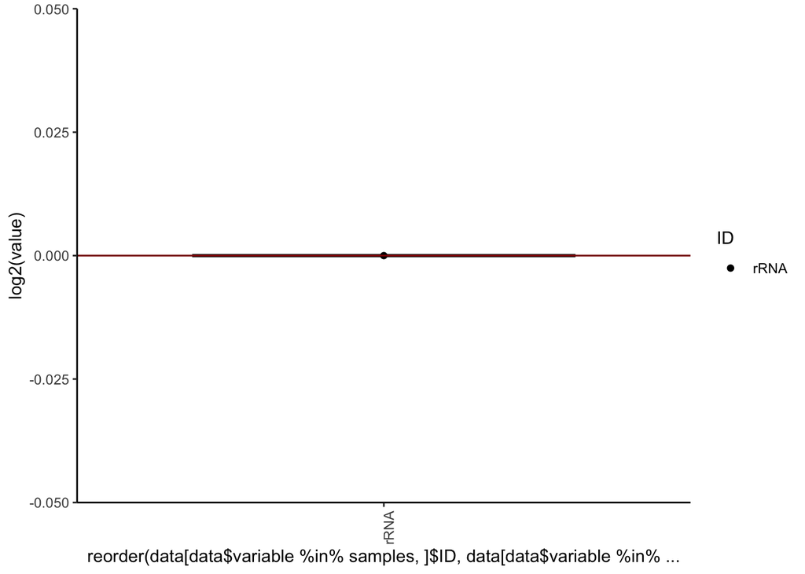

```r
# Counts for features at the transcript level
features$transcript
```

|  | s1 | c1 |
| --- | --- | --- |
| ENSG000000XXXXX_NR003286-2_RN18S1_rRNA | 800 | 600 |
| ENSG00000XXXXXX_NR003287-2_RN28S1_rRNA | 200 | 200 |

```r
# Counts for features at the family level (last field with  "_" delimited IDs)
features$family
```

| ID | s1 | c1 | norm_1 |
| --- | --- | --- | --- |
| rRNA | 1000 | 800 | 1 |

## 4.4 Clustering

In the COMRADES data, crosslinking and fragmentation leads to the production of redundant structural information, where the same in vivo structure from different RNA molecules produces slightly different RNA fragments. Clustering of these duplexes that originate from the same place in the reference transcript reduces computational time and allows trimming of these clusters to improve the folding prediction. To allow clustering, gapped alignments can be described by the transcript coordinates of the left (L) and right (R) side of the reads and by the nucleotides between L and R (g). Reads with similar or identical g values are likely to originate from the same structure of different molecules. In COMRADES-OO, an adjacency matrix is created for all chimeric reads based on the nucleotide difference between their g values (Deltagap). This results in Deltagap = 0 for identically overlapping gaps and increasing Deltagap values for gapped reads with less overlap:

- Deltagap(gi,gj) = max(width(gi),width(gj)) – widthofIntersection(gi,gj)

For short range interactions ( g <= 10 nt ) the weights are calculated such that the highest weights are given to exactly overlapping gapped alignments and a weight of 0 is assigned to alignments that do not overlap.

- E(gi, gj) = 10 - Deltagap(gi, gj)

Long range interactions (g >10) are clustered separately and their weights are calculated as follows and edges with weights lower that 0 are set to 0. Meaning that gaps that do not overlap by at least 15 nucleotides are considered in different clusters.

- E(gi, gj) = 15 - Deltagap(gi, gj)

From these weights the network can be defined for short- and long-range interaction as: G = (V, E). To identify clusters within the graph (subgraphs) the graph is clustered using random walks with the cluster_waltrap function (steps = 2) from the iGraph packageå, there is an option for users to remove clusters with less than a specified amount of reads. These clusters often contain a small number of longer L or R sequences due to the random fragmentation in the COMRADES protocol.

```r
# Cluster the reads
clusteredCds = clusterComrades(cds = cds,         # The comradesDataSet instance
                               cores = 1,         # The number of cores
                               stepCount = 2,     # The number of steps in the random walk
                               clusterCutoff = 1) # The minimum number of reads for a cluster to be considered
```

```
#> ****  ENSG000000XXXXX_NR003286-2_RN18S1_rRNA  *****
#> ****               1870  nt             ****
#> ****       Assessing Long Range         ****
#> ****        Sampling Long Range         ****
#> ****      Assessing Short Range         ****
#> ****      Sampling short Range          ****
#> *****        done  s1 1  / 1           *****
#> *****        done  c1 1  / 1           *****
#> *****          Creating object         *****
```

```r
# Check status of instance
clusteredCds
```

```
#> comradesDataSet Object
#> RNAs Analysed                -              -  ENSG000000XXXXX_NR003286-2_RN18S1_rRNA
#> Samples Analysed             -              -  s1 c1
#> hybFiles           - Raw data               -  original host noHost
#> matrixList         - Contact Matricies      -  noHost original originalClusters
#> clusterTableList   - Cluster positions      -  original
#> clusterGrangesList - Granges of clusters    -  original
#> interactionTable   - Predictied interaction -  0
#> viennaStructures   - Predicted Structures   - 0
```

### 4.4.1 Cluster Numbers

```r
# Returns the number of clusters in each sample
clusterNumbers(clusteredCds)
```

| file | group | sample | sampleName | rna | original |
| --- | --- | --- | --- | --- | --- |
| /private/var/folders/dy/86vcj54d7bsgh2_dpqlf4l600000gn/T/RtmpB8ZReM/Rinst76c01edcdff1/comradesOO/extdata/s1.txt | s | 1 | s1 | ENSG000000XXXXX_NR003286-2_RN18S1_rRNA | 119 |
| /private/var/folders/dy/86vcj54d7bsgh2_dpqlf4l600000gn/T/RtmpB8ZReM/Rinst76c01edcdff1/comradesOO/extdata/c1.txt | c | 1 | c1 | ENSG000000XXXXX_NR003286-2_RN18S1_rRNA | 90 |

### 4.4.2 Read numbers in clusters

```r
# Returns the number reads in clusters
readNumbers( clusteredCds)
```

| file | group | sample | sampleName | rna | original | host | noHost | all |
| --- | --- | --- | --- | --- | --- | --- | --- | --- |
| /private/var/folders/dy/86vcj54d7bsgh2_dpqlf4l600000gn/T/RtmpB8ZReM/Rinst76c01edcdff1/comradesOO/extdata/s1.txt | s | 1 | s1 | ENSG000000XXXXX_NR003286-2_RN18S1_rRNA | 1108 | 1000 | 800 | 1000 |
| /private/var/folders/dy/86vcj54d7bsgh2_dpqlf4l600000gn/T/RtmpB8ZReM/Rinst76c01edcdff1/comradesOO/extdata/c1.txt | c | 1 | c1 | ENSG000000XXXXX_NR003286-2_RN18S1_rRNA | 842 | 800 | 600 | 800 |

### 4.4.3 Cluster Tables

The cluster tables contain coordinates of the clusters in data.frame format. Each cluster has a unique ID and size.x corrasponds to the number of reads assigned to that cluster or supercluster. ls, le, rs and le give the coordinates of the interaction.

```r
getData(clusteredCds,        # The object
        "clusterTableList",  # The Type of data to return
        "original")[[1]]     # The stage of the analysis for the return data
```

|  | id | ls | le | rs | re | size.Group.1 | size.x |
| --- | --- | --- | --- | --- | --- | --- | --- |
| 10:binLong:1 left | 10:binLong:1 left | 478 | 559 | 574 | 612 | 10:binLong:1 | 8 |
| 10:binShort:1 left | 10:binShort:1 left | 368 | 497 | 496 | 622 | 10:binShort:1 | 20 |
| 11:binLong:1 left | 11:binLong:1 left | 1220 | 1287 | 1481 | 1595 | 11:binLong:1 | 6 |
| 11:binShort:1 left | 11:binShort:1 left | 630 | 684 | 688 | 809 | 11:binShort:1 | 38 |
| 12:binLong:1 left | 12:binLong:1 left | 115 | 202 | 287 | 346 | 12:binLong:1 | 4 |
| 12:binShort:1 left | 12:binShort:1 left | 678 | 774 | 774 | 819 | 12:binShort:1 | 4 |
| 13:binLong:1 left | 13:binLong:1 left | 120 | 178 | 224 | 356 | 13:binLong:1 | 14 |
| 13:binShort:1 left | 13:binShort:1 left | 135 | 161 | 163 | 235 | 13:binShort:1 | 4 |
| 14:binLong:1 left | 14:binLong:1 left | 143 | 190 | 220 | 374 | 14:binLong:1 | 6 |
| 14:binShort:1 left | 14:binShort:1 left | 1047 | 1190 | 1194 | 1234 | 14:binShort:1 | 4 |

[output cut: 109 more lines]

### 4.4.4 Cluster GRanges

You can also extract a GRanges object of the individual reads and their cluster membership:

```r
getData(clusteredCds,         # The object
        "clusterGrangesList", # The Type of data to return
        "original")[[1]]      # The stage of the analysis for the return data
```

## 4.5 Cluster Trimming

Given the assumption that the reads within each cluster likely originate from the same structure in different molecules these clusters can be trimmed to contain the regions from L and R that have the most evidence the clustering and trimming is achieved with the clusterComrades and trimClusters methods.

```r
# Trim the Clusters
trimmedClusters = trimClusters(clusteredCds = clusteredCds, # The comradesDataSet instance
                               trimFactor = 1,              # The cutoff for cluster trimming (see above)
                               clusterCutoff = 0)          # The minimum number of reads for a cluster to be considered
```

```
#> ******        Trimming Clusters       ******
#> ******            Saving              ******
#> ******        Saving mat list         ******
#> ******       Saving table list        ******
#> ******           Saving  End          ******
#> ******      Saving mat list  End      ******
#> ******     Saving granges list        ******
#> ******     Saving table list  End     ******
```

```r
# Check status of instance
trimmedClusters
```

```
#> comradesDataSet Object
#> RNAs Analysed                -              -  ENSG000000XXXXX_NR003286-2_RN18S1_rRNA
#> Samples Analysed             -              -  s1 c1
#> hybFiles           - Raw data               -  original host noHost
#> matrixList         - Contact Matricies      -  noHost original originalClusters superClusters trimmedClusters
#> clusterTableList   - Cluster positions      -  original superClusters trimmedClusters
#> clusterGrangesList - Granges of clusters    -  original superClusters trimmedClusters
#> interactionTable   - Predictied interaction -  0
#> viennaStructures   - Predicted Structures   - 0
```

```r
# Returns the number of clusters in each sample
clusterNumbers(trimmedClusters)
```

| file | group | sample | sampleName | rna | original | superClusters | trimmedClusters |
| --- | --- | --- | --- | --- | --- | --- | --- |
| /private/var/folders/dy/86vcj54d7bsgh2_dpqlf4l600000gn/T/RtmpB8ZReM/Rinst76c01edcdff1/comradesOO/extdata/s1.txt | s | 1 | s1 | ENSG000000XXXXX_NR003286-2_RN18S1_rRNA | 119 | 85 | 85 |
| /private/var/folders/dy/86vcj54d7bsgh2_dpqlf4l600000gn/T/RtmpB8ZReM/Rinst76c01edcdff1/comradesOO/extdata/c1.txt | c | 1 | c1 | ENSG000000XXXXX_NR003286-2_RN18S1_rRNA | 90 | 72 | 72 |

```r
# Returns the number reads in clusters
readNumbers( trimmedClusters)
```

| file | group | sample | sampleName | rna | original | host | noHost | all | superClusters | trimmedClusters |
| --- | --- | --- | --- | --- | --- | --- | --- | --- | --- | --- |
| /private/var/folders/dy/86vcj54d7bsgh2_dpqlf4l600000gn/T/RtmpB8ZReM/Rinst76c01edcdff1/comradesOO/extdata/s1.txt | s | 1 | s1 | ENSG000000XXXXX_NR003286-2_RN18S1_rRNA | 1108 | 1000 | 800 | 1000 | 1108 | 1108 |
| /private/var/folders/dy/86vcj54d7bsgh2_dpqlf4l600000gn/T/RtmpB8ZReM/Rinst76c01edcdff1/comradesOO/extdata/c1.txt | c | 1 | c1 | ENSG000000XXXXX_NR003286-2_RN18S1_rRNA | 842 | 800 | 600 | 800 | 842 | 842 |

see Plotting contact matrices.

## 4.6 Folding

The final step is folding, this step populates the `viennaStructures`, `dgs` and `interactionTable` slots. This step can only be run if you have the Vienna package installed and RNAFold in your PATH.

```r
# Fold the RNA in part of whole
foldedCds = foldComrades(trimmedClusters,
                         rnaRefs = rnaRefs,
                         start = 1600,
                         end = 1869,
                         shape = 0,
                         ensembl = 20,
                         constraintNumber  = 30,
                         evCutoff = 5)
```

```r
# Check status of instance
foldedCds
```

# 5 Other Plots and Functionality

## 5.1 Plotting contact matrices

Plots can be made for each sample using the *plotMatrices* function.

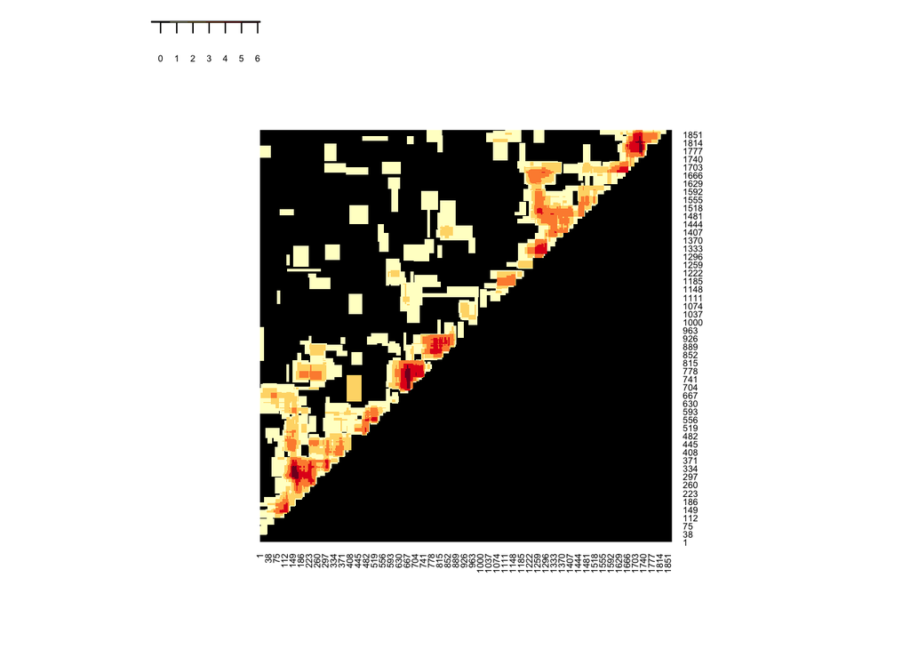

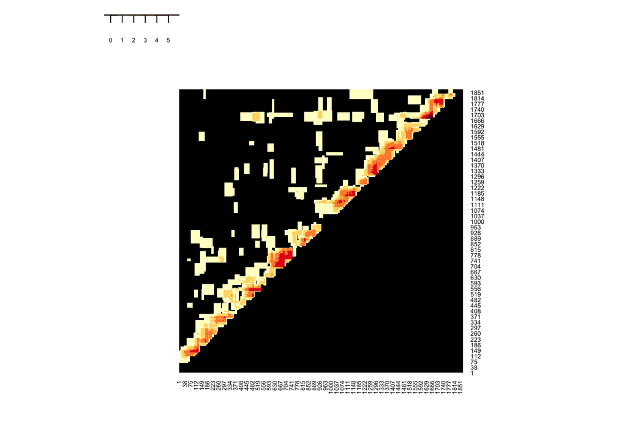

```r
# Plot heatmaps for each sample
plotMatrices(cds = cds,         # The comradesDataSet instance
             type = "original", # The "analysis stage"
             directory = 0,     # The directory for output (0 for standard out)
             a = 1,             # Start coord for x-axis
             b = rnaSize(cds),  # End coord for x-axis
             c = 1,             # Start coord for y-axis
             d = rnaSize(cds),  # End coord for y-axis
             h = 5)             # The hight of the image (if saved)
```

See which contact maps are available by checking the status of the object

```r
trimmedClusters
```

```
#> comradesDataSet Object
#> RNAs Analysed                -              -  ENSG000000XXXXX_NR003286-2_RN18S1_rRNA
#> Samples Analysed             -              -  s1 c1
#> hybFiles           - Raw data               -  original host noHost
#> matrixList         - Contact Matricies      -  noHost original originalClusters superClusters trimmedClusters
#> clusterTableList   - Cluster positions      -  original superClusters trimmedClusters
#> clusterGrangesList - Granges of clusters    -  original superClusters trimmedClusters
#> interactionTable   - Predictied interaction -  0
#> viennaStructures   - Predicted Structures   - 0
```

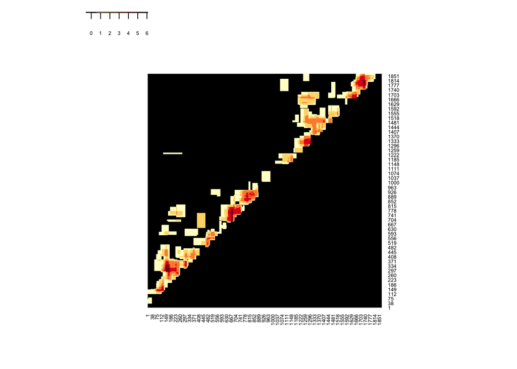

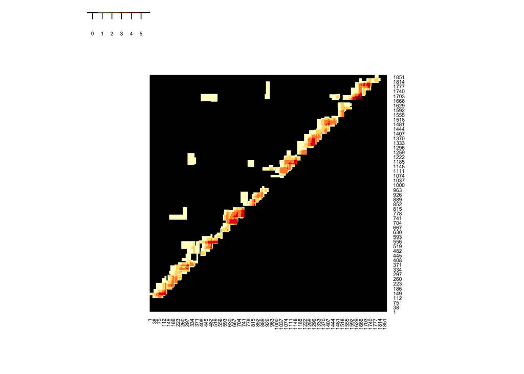

```r
# Plot heatmaps for all samples combined and all controls combined
plotMatricesAverage(cds = trimmedClusters, # The comradesDataSet instance
             type = "trimmedClusters", # The "analysis stage"
             directory = 0,     # The directory for output (0 for standard out)
             a = 1,             # Start coord for x-axis
             b = rnaSize(cds),  # End coord for x-axis
             c = 1,             # Start coord for y-axis
             d = rnaSize(cds),  # End coord for y-axis
             h = 5)             # The hight of the image (if saved)
```

## 5.2 Identifying domains

With large RNAS (?500bp), it can be useful to segment the RNA and fold the segments seaparately. DNA and RNA that form secondary and tertiary structures often have domains where there is more inter-domain interactions that inra-domain interactions. The *TopDom* package was designed to identify these domains for HI-C data. Using this package you can identify domains in the RNA structural data and can be used to inform the folding.

```r
domainDF = data.frame()
for(j in c(20,30,40,50,60,70)){
    #for(i in which(sampleTable(cds)$group == "s")){

    timeMats = as.matrix(getData(x = cds,
                                 data = "matrixList",
                                 type = "noHost")[[1]])

    timeMats = timeMats/ (sum(timeMats)/1000000)
    tmp = tempfile()
    write.table(timeMats, file = tmp,quote = F,row.names = F, col.names = F)

    tdData2 = readHiC(
        file = tmp,
        chr = "rna18s",
        binSize = 10,
        debug = getOption("TopDom.debug", FALSE)
    )

    tdData =  TopDom(
        tdData2 ,
        window.size = j,
        outFile = NULL,
        statFilter = TRUE,
        debug = getOption("TopDom.debug", FALSE)
    )

    td = tdData$domain
    td$sample = sampleTable(cds)$sampleName[1]
    td$window = j
    domainDF = rbind.data.frame(td, domainDF)

}



ggplot(domainDF) +
    geom_segment(aes(x = from.coord/10,
                     xend = to.coord/10, y = as.factor(sub("s","",sample)),
                     yend = (as.factor(sub("s","",sample)) ), colour = tag),
                 size  = 20, alpha = 0.8) +
    facet_grid(window~.)+
    theme_bw()
```

## 5.3

[figure not shown]

## 5.4 Analyse folds

### 5.4.1 Ensemble Stats

### 5.4.2 HotSpots of difference

### 5.4.3 PCA of ensembl

A PCA of the structural ensembl can be made.

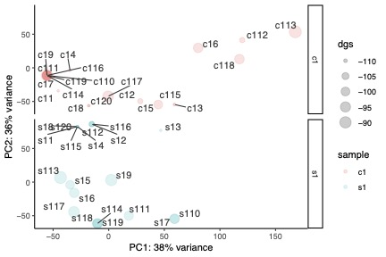

```r
plotEnsemblePCA(foldedCds,
                labels = T, # plot labels for structures
                split = T)  # split samples over different facets (T/f)
```

### 5.4.4 Plot to strcutures on an arc diagram

Compare two structures from the ensembl

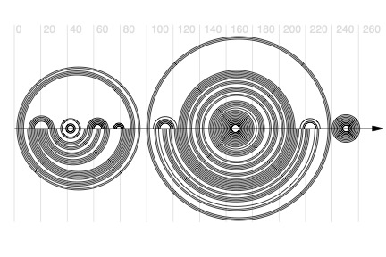

```r
plotComparisonArc(foldedCds = foldedCds,
                  s1 = "c1",            # The sample of the 1st structure
                  s2 = "s1",            # The sample of the 2nd structure
                  n1 = 13,               # The number of the 1st structure
                  n2 = 16)               # The number of the 2nd structure
```

### 5.4.5 Plot one structure

```r
plotStructure(foldedCds = foldedCds,
              rnaRefs = rnaRefs,
              s = "s1",          # The sample of the structure
              n = 1)             # The number of the structure
```

## 5.5 Inter RNA interactions- Plot an interacting partner

Along with the RNA of interest the data also contains inter-RNA interactions with other RNAs from the transcriptome reference. After identifying abundant interactions using topInteractions you can find out where on each RNA these inetractions occur using *getInteractions* and *getReverseInteractions*.

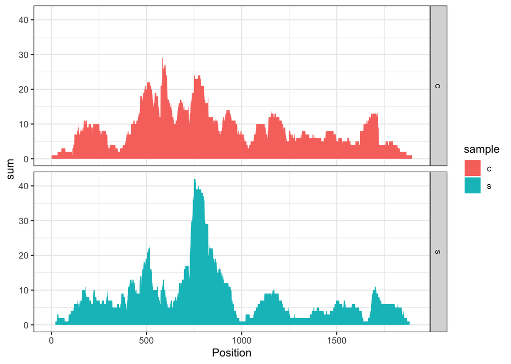

```r
getInteractions(cds,
                "ENSG00000XXXXXX_NR003287-2_RN28S1_rRNA") %>%
    mutate(sample =sub("\\d$","",sample) )%>%
    group_by(rna,Position,sample)%>%
    summarise(sum =  sum(depth)) %>%
    ggplot()+
    geom_area(aes(x = Position,
                  y = sum,
                  fill = sample),
              stat = "identity")+
    facet_grid(sample~.) +
    theme_bw()
```

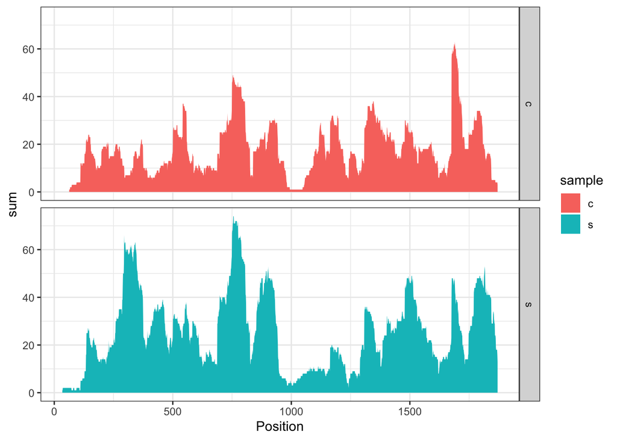

```r
getReverseInteractions(cds,
                       rna) %>%
    mutate(sample =sub("\\d$","",sample) )%>%
    group_by(rna,Position,sample)%>%
    summarise(sum =  sum(depth)) %>%
    ggplot()+
    geom_area(aes(x = Position,
                  y = sum,
                  fill = sample),
                    stat = "identity")+
    facet_grid(sample~.)+
    theme_bw()
```

## 5.6 Compare to the “Known” structure

The clusters can be compared to set of interactions to see which clusters share coordinates with a this set of interactions. The table should be formatted as a tabale fame of 2 columns (i and j) each colunn containing numerical values giving an interaction between i and j with which the clusters should be compared.

### 5.6.1 Make a contact matrix of known / comprative interactions

To compare to set of know interactions you need a contact matrix these interactions, for plotting it is sometimes useful to expand the interactions so they can be seen easily.

```r
expansionSize = 5
knownMat = matrix(0, nrow = rnaSize(cds), ncol = rnaSize(cds))
for(i in 1:nrow(known18S)){
    knownMat[ (known18S$V1[i]-expansionSize):(known18S$V1[i]+expansionSize),
              (known18S$V2[i]-expansionSize):(known18S$V2[i]+expansionSize)] =
        knownMat[(known18S$V1[i]-expansionSize):(known18S$V1[i]+expansionSize),
                 (known18S$V2[i]-expansionSize):(known18S$V2[i]+expansionSize)] +1
}
knownMat = knownMat + t(knownMat)
```

### 5.6.2 Compare the Clusters

Using *compareKnown* you can check which clusters agree with the set of interactions. This functions adds analysis stages “known”, “novel” and “knownAndNovel” to the objects data attributes.

```r
# use compare known to gett he known and not know clusters
knowClusteredCds = compareKnown(trimmedClusters, # The comradesDataSet instance
                                knownMat, # A contact matrix of know interactions
                                "trimmedClusters") # The analysis stage of clustering to compare

knowClusteredCds
```

```
#> comradesDataSet Object
#> RNAs Analysed                -              -  ENSG000000XXXXX_NR003286-2_RN18S1_rRNA
#> Samples Analysed             -              -  s1 c1
#> hybFiles           - Raw data               -  original host noHost
#> matrixList         - Contact Matricies      -  noHost original originalClusters superClusters trimmedClusters KnownAndNovel novel known
#> clusterTableList   - Cluster positions      -  original superClusters trimmedClusters novel known
#> clusterGrangesList - Granges of clusters    -  original superClusters trimmedClusters
#> interactionTable   - Predictied interaction -  0
#> viennaStructures   - Predicted Structures   - 0
```

### 5.6.3 Plot the overlapping clusters

You can plot these using the *plotMatrices* function

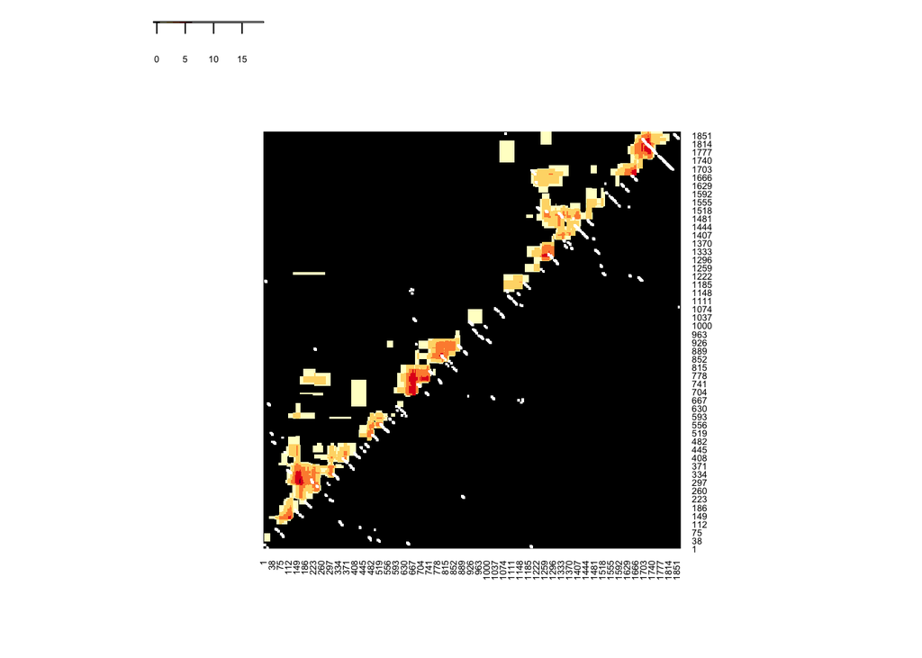

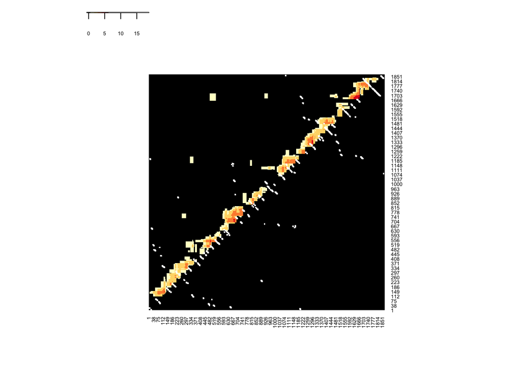

```r
# Plot heatmaps for all samples combined and all controls combined
plotMatricesAverage(cds = knowClusteredCds, # The comradesDataSet instance
             type = "KnownAndNovel", # The "analysis stage"
             directory = 0,     # The directory for output (0 for standard out)
             a = 1,             # Start coord for x-axis
             b = rnaSize(cds),  # End coord for x-axis
             c = 1,             # Start coord for y-axis
             d = rnaSize(cds),  # End coord for y-axis
             h = 5)             # The hight of the image (if saved)
```

### 5.6.4 Cluster Numbers

```r
# Get the number of clusters for each analysis Stage
clusterNumbers(knowClusteredCds)
```

| file | group | sample | sampleName | rna | original | superClusters | trimmedClusters | novel | known |
| --- | --- | --- | --- | --- | --- | --- | --- | --- | --- |
| /private/var/folders/dy/86vcj54d7bsgh2_dpqlf4l600000gn/T/RtmpB8ZReM/Rinst76c01edcdff1/comradesOO/extdata/s1.txt | s | 1 | s1 | ENSG000000XXXXX_NR003286-2_RN18S1_rRNA | 119 | 85 | 85 | 39 | 46 |
| /private/var/folders/dy/86vcj54d7bsgh2_dpqlf4l600000gn/T/RtmpB8ZReM/Rinst76c01edcdff1/comradesOO/extdata/c1.txt | c | 1 | c1 | ENSG000000XXXXX_NR003286-2_RN18S1_rRNA | 90 | 72 | 72 | 30 | 42 |

### 5.6.5 Read numbers in clusters

```r
# Get the number of reads in each cluster for each analysis stage
readNumbers(knowClusteredCds)
```

| file | group | sample | sampleName | rna | original | host | noHost | all | superClusters | trimmedClusters |
| --- | --- | --- | --- | --- | --- | --- | --- | --- | --- | --- |
| /private/var/folders/dy/86vcj54d7bsgh2_dpqlf4l600000gn/T/RtmpB8ZReM/Rinst76c01edcdff1/comradesOO/extdata/s1.txt | s | 1 | s1 | ENSG000000XXXXX_NR003286-2_RN18S1_rRNA | 1108 | 1000 | 800 | 1000 | 1108 | 1108 |
| /private/var/folders/dy/86vcj54d7bsgh2_dpqlf4l600000gn/T/RtmpB8ZReM/Rinst76c01edcdff1/comradesOO/extdata/c1.txt | c | 1 | c1 | ENSG000000XXXXX_NR003286-2_RN18S1_rRNA | 842 | 800 | 600 | 800 | 842 | 842 |

### 5.6.6 Compare structures with known

To compare predicted structures with the know stucture use “compareKnownStructures”. This will give you the number of base pairs that agree between the ensembl of predicted structures and the structure imputted for comparison. This can be for better viewing.

```r
head(compareKnownStructures(foldedCds,
                            known18S)) # the comarison set
```

```r
ggplot(compareKnownStructures(foldedCds, known18S)) +
    geom_hline(yintercept = c(0.5,0.25,0.75,0,1),
               colour = "grey",
               alpha = 0.2)+
    geom_vline(xintercept = c(0.5,0.25,0.75,0,1),
               colour = "grey",
               alpha = 0.2)+
    geom_point(aes(x = sensitivity,
                   y = precision,
                   size = as.numeric(as.character(unlist(foldedCds@dgs))),
                   colour = str_sub(structureID,
                                    start = 1 ,
                                    end = 2))) +
    xlim(0,1)+
    ylim(0,1)+
    theme_classic()
```

# 6 Quick start

The package ships with a subsetted version of the unenriched dataset which can be used to follow the vignette, the full dataset can be found here: [Un-enriched rRNA dataset](https://www.ncbi.nlm.nih.gov/geo/query/acc.cgi?acc=GSE246412). There is also a function `makeExampleComradesDataSet()` from the comradesOO package that will create a simple toy example comradesDataSet object, follow this small section to get a feel for the package and it’s functionality. The dataset has 1 sample consisting of a control and sample.

```r
# make an example dataset
cds = makeExampleComradesDataSet()
cds
```

By plotting the reads on a 2D heatmap you can see structured areas of the transcript and long / short distance inter-RNA interactions. The “type” argument can be changed to plot any analysis stage in the matrixList slot which will become populated as the analysis proceeds.

```r
# Have a look at the reads for each sample
plotMatricesAverage(cds = cds,
                    type = "original",
                    directory = 0,
                    a = 1,
                    b = rnaSize(cds),
                    c = 1,
                    d = rnaSize(cds),
                    h = 5)
```

Find the RNAs that interact with the RNA of interest.

```r
topInteracters(cds,2)
```

Get some more information about the RNAs in the sample and thier abundance in each sample. With more RNAS and transcripts this becomes very useful as a count matrix.

```r
featureInfo(cds)
```

Clustering and cluster trimming.

```r
clusteredCds = clusterComrades(cds = cds,
                               cores = 1,
                               stepCount = 2,
                               clusterCutoff = 0)






trimmedClusters = trimClusters(clusteredCds = clusteredCds,
                               trimFactor = 1,
                               clusterCutoff = 0)
```

Plot them to check the clustering and trimming is working as expected.

```r
plotMatricesAverage(cds = clusteredCds,
                    type = "originalClusters",
                    directory = 0,
                    a = 1,
                    b = rnaSize(cds),
                    c = 1,
                    d = rnaSize(cds),
                    h = 5)
```

```r
plotMatricesAverage(cds = trimmedClusters,
                    type = "trimmedClusters",
                    directory = 0,
                    a = 1,
                    b = rnaSize(cds),
                    c = 1,
                    d = rnaSize(cds),
                    h = 5)
```

Folding:

```r
fasta = paste(c(rep('A',25),
                rep('T',25),
                rep('A',10),
                rep('T',23)),collapse = "")

header = '>transcript1'


fastaFile = tempfile()
writeLines(paste(header,fasta,sep = "\n"),con = fastaFile)


rnaRefs = list()
rnaRefs[[rnas(cds)]] = read.fasta(fastaFile)
rnaRefs



foldedCds = foldComrades(trimmedClusters,
                         rnaRefs = rnaRefs,
                         start = 1,
                         end = 83,
                         shape = 0,
                         ensembl = 5,
                         constraintNumber  = 1,
                         evCutoff = 1)
```

If you have a set of nucloetide contacts, you can check to see if they exist in the set of predicted structures after folding. Also see `compareKnown` which is a similar function but tests the set of interactions against the clusters.

```r
# make an example table of "know" interactions
file = data.frame(V1 = c(6),
                  V2 = c(80))

compareKnownStructures(foldedCds,file)
```

Plot a PCA of the predicted structures

```r
plotEnsemblePCA(foldedCds, labels = T,split = T)
```

Compare two structures

```r
plotComparisonArc(foldedCds = foldedCds,"s1","c1",2,3)
```

Plot one structure

```r
plotStructure(foldedCds = foldedCds,"c1",1)
```